# HW 06: APIs and Web Scraping

YASHVI MALVIYA

2023-10-31

© 2023 David Gerard, not to be posted online.

# Instructions

- Write your solutions in this starter file. You should modify the “author” field in the YAML header.
- Only commit R Markdown and HTML files (no PDF files). Make sure you have knitted to HTML for your final submission.
- **Make sure to commit each time you answer a question.**
- Only include the necessary code, not any extraneous code, to answer the questions.
- Learning objectives:
  - Obtain data from an API.
  - Scrape data from the web.

# Open Brewery Database

Consider the Open Brewery Database API: https://www.openbrewerydb.org/

Only use `{httr2}`, not `{httr}`.

```r
library(rvest)
library(httr2)
library(tidyverse)
library(jsonlite)
library(request)
```

```r
library(dplyr)
library(tibble)
library(ggplot2)
library(maps)
library(rvest)
library(tidyr)
```

1. (1 pt) Get the list of all micro breweries in Ohio (163 of them) where we have longitude and latitude information (124 of them). These should be the microbreweries you obtained:

```r
base_url <- "https://api.openbrewerydb.org/breweries"

parameters <- list(
  "by_state" = "Ohio",
  "per_page" = 163,
  "page" = 1,
  "by_type" = "micro"
)

response <- GET(base_url, query = parameters)

breweries<- content(response, "parsed", type = "application/json")

names_list <- lapply(breweries, function(brewery) brewery$name)

brewery_names <- tibble(Name = unlist(names_list))

print(brewery_names)
```

```
## # A tibble: 163 × 1
##    Name
##    <chr>
##  1 13 Below Brewery
##  2 2 Tones Brewing Co.
##  3 Actual Brewing Company, LLC
##  4 Akronym Brewing LLC
##  5 Antiques on High
##  6 Aqueduct Brewing
##  7 Bad Tom Smith Brewing
##  8 Bardwell Winery and Brewery
##  9 Bascule Brewery And Public House
## 10 Biker Brew House
## # ℹ 153 more rows
```

2. (1 pt) Clean up the data from part 1 to get the following data frame:

```r
brewery_df <- as.data.frame(do.call(rbind, breweries))

cleaned_data <- tibble(
  id = as.character(brewery_df$id),
  name = as.character(brewery_df$name),
  address_1 = as.character(brewery_df$address_1),
  city = as.character(brewery_df$city),
  state_province = as.character(brewery_df$state_province),
  postal_code = as.character(brewery_df$postal_code),
  longitude = as.character(brewery_df$longitude),
  latitude = as.character(brewery_df$latitude),
  phone = as.character(brewery_df$phone),
  website_url = as.character(brewery_df$website_url),
  street = as.character(brewery_df$street)
)


cleaned_data <- cleaned_data %>%
  filter(latitude != "NULL" & longitude != "NULL")



cleaned_data$latitude <- as.numeric(cleaned_data$latitude)
cleaned_data$longitude <- as.numeric(cleaned_data$longitude)


x <- cleaned_data%>%
        as_tibble()

print(x)
```

```
## # A tibble: 124 × 11
##    id        name  address_1 city  state_province postal_code longitude latitude
##    <chr>     <chr> <chr>     <chr> <chr>          <chr>           <dbl>    <dbl>
##  1 950180bd… 13 B… 7391 For… Cinc… Ohio           45233-1013      -84.7     39.1
##  2 836cb05e… 2 To… 4539 E B… Whit… Ohio           43213-1308      -82.9     40.0
##  3 ea7f7091… Actu… 655 N Ja… Colu… Ohio           43219-1837      -82.9     40.0
##  4 d4f4e76b… Akro… 58 E Mar… Akron Ohio           44308           -81.5     41.1
##  5 1c215e2f… Anti… 714 S Hi… Colu… Ohio           43206           -83.0     39.9
##  6 fc2ce5e0… Aque… 529 Gran… Akron Ohio           44311-1184      -81.5     41.1
##  7 ccb3350f… Bad … 4720 Eas… Cinc… Ohio           45226-1893      -84.4     39.1
##  8 7574d2fa… Bard… 716 N Hi… Moun… Ohio           45154           -83.9     39.0
##  9 d73def5b… Basc… 1397 Col… Lora… Ohio           44052-3377      -82.2     41.5
## 10 55cf083b… Bird… 16 S Mai… Colu… Ohio           44408-1348      -80.7     40.9
## # ℹ 114 more rows
## # ℹ 3 more variables: phone <chr>, website_url <chr>, street <chr>
```

3. (1 pt) Edit the following ggplot code to obtain the following plot:

   ```r
   library(maps)
   countymap <- map_data("county")

   countymap |>
     filter(region == "ohio") |>
     ggplot(aes(x = long, y = lat, group = subregion)) +
     geom_polygon(fill = "white", color = "black")
   ```

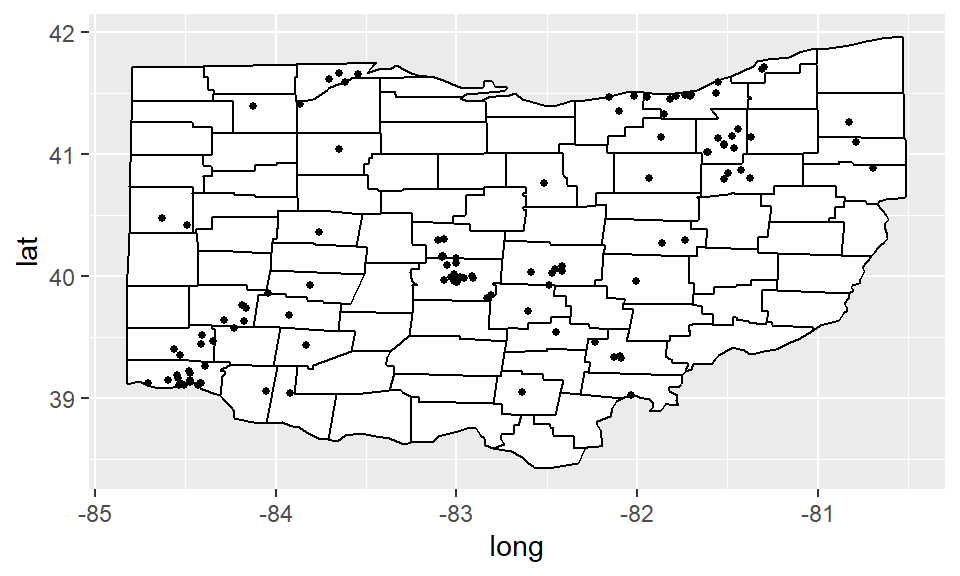

```r
countymap <- map_data("county")
ohio_map <- countymap %>%
  filter(region == "ohio")


brewery_map <- ggplot() +
  geom_polygon(data = ohio_map, aes(x = long, y = lat, group = group), fill = "white", color = "black") +
  geom_point(data = cleaned_data, aes(x = longitude, y = latitude), color = "black", size = 1)


brewery_map
```

# English women artists

Consider the copied Wikipedia page on English women artists: https://data-science-master.github.io/lectures/data/engart.html

We’ll use the copied version on GitHub rather than the original version to make sure solutions are consistent. But the original version can be found here (but don’t use it): https://en.wikipedia.org/wiki/List_of_English_women_artists

Use rvest to answer the following questions.

1. (1 pt) Download the html file and save the output to a variable.

```r
url <- "https://data-science-master.github.io/lectures/data/engart.html"

html_content <- read_html(url)
```

```r
html_elements(x=html_content, css = " ul:nth-child(5) li , ul:nth-child(7) li , ul:nth-child(9) li , ul:nth-child(11) li , ul:nth-child(13) li , ul:nth-child(15) li , ul:nth-child(17) li , ul:nth-child(19) li , ul:nth-child(21) li , ul:nth-child(23) li , ul:nth-child(25) li , ul:nth-child(27) li , ul:nth-child(29) li , ul:nth-child(31) li , ul:nth-child(33) li , ul:nth-child(35) li , ul:nth-child(37) li , ul:nth-child(39) li , ul:nth-child(41) li , ul:nth-child(43) li , ul:nth-child(45) li , ul:nth-child(49) li ")
```

```
## {xml_nodeset (293)}
##  [1] <li>\n<a href="/wiki/Evelyn_Abelson" title="Evelyn Abelson">Evelyn Abels ...
##  [2] <li>\n<a href="/wiki/Ruth_Abrahams" title="Ruth Abrahams">Ruth Abrahams< ...
##  [3] <li>\n<a href="/wiki/Judith_Ackland" title="Judith Ackland">Judith Ackla ...
##  [4] <li>\n<a href="/wiki/Elinor_Proby_Adams" title="Elinor Proby Adams">Elin ...
##  [5] <li>\n<a href="/wiki/Sarah_Gough_Adamson" title="Sarah Gough Adamson">Sa ...
##  [6] <li>\n<a href="/wiki/Marion_Adnams" title="Marion Adnams">Marion Adnams< ...
##  [7] <li>\n<a href="/wiki/Mary_Adshead" title="Mary Adshead">Mary Adshead</a> ...
##  [8] <li>\n<a href="/wiki/Eileen_Agar" title="Eileen Agar">Eileen Agar</a> (1 ...
##  [9] <li>\n<a href="/wiki/Sam_Ainsley" title="Sam Ainsley">Sam Ainsley</a> (b ...
## [10] <li>\n<a href="/wiki/Eileen_Aldridge" title="Eileen Aldridge">Eileen Ald ...
## [11] <li>\n<a href="/wiki/Griselda_Allan" title="Griselda Allan">Griselda All ...
## [12] <li>\n<a href="/wiki/Rosemary_Allan" title="Rosemary Allan">Rosemary All ...
## [13] <li>\n<a href="/wiki/Daphne_Allen" title="Daphne Allen">Daphne Allen</a> ...
## [14] <li>\n<a href="/wiki/Kathleen_Allen" title="Kathleen Allen">Kathleen All ...
## [15] <li>\n<a href="/wiki/Helen_Allingham" title="Helen Allingham">Helen Alli ...
## [16] <li>\n<a href="/wiki/Anna_Alma-Tadema" title="Anna Alma-Tadema">Anna Alm ...
## [17] <li>\n<a href="/wiki/Laura_Theresa_Alma-Tadema" title="Laura Theresa Alm ...
## [18] <li>\n<a href="/wiki/Marie_Angel_(artist)" title="Marie Angel (artist)"> ...
## [19] <li>\n<a href="/wiki/Mabel_Annesley" title="Mabel Annesley">Mabel Annesl ...
## [20] <li>\n<a href="/wiki/Amanda_Ansell" title="Amanda Ansell">Amanda Ansell< ...
## ...
```

3. (2 pts) Clean the data.

   Hints:
   1. Not all year ranges are of the form (Birth-Death). You should place NA’s in the appropriate locations. No need to extract third-party datasets to obtain the true values.
   2. Be careful of parsing numbers like `"c.1888"`.
   3. Parentheses are used more than just to delimit years.
   4. Painters, sculptors, illustrators, and printmakers are the most common types of artists, so I included indicators for those mediums. Note that not all printmakers are called “printmakers”.

   Your final data frame should look like this:

```r
css_selector <- "ul:nth-child(5) li , ul:nth-child(7) li , ul:nth-child(9) li , ul:nth-child(11) li , ul:nth-child(13) li , ul:nth-child(15) li , ul:nth-child(17) li , ul:nth-child(19) li , ul:nth-child(21) li , ul:nth-child(23) li , ul:nth-child(25) li , ul:nth-child(27) li , ul:nth-child(29) li , ul:nth-child(31) li , ul:nth-child(33) li , ul:nth-child(35) li , ul:nth-child(37) li , ul:nth-child(39) li , ul:nth-child(41) li , ul:nth-child(43) li , ul:nth-child(45) li , ul:nth-child(49) li"


data <- html_content %>%
  html_elements(css = css_selector) %>%
  html_text() %>%
  as.data.frame()


colnames(data) <- "raw.data"

data$artist <- sub(" \\(\\d{4}–\\d{4}\\), .*$", "", data$raw.data)
data$birth <- as.numeric(sub(".*\\((\\d{4})–\\d{4}\\), .*$", "\\1", data$raw.data))
data$death <- as.numeric(gsub(".*(\\d{4})\\).*", "\\1", data$raw.data))
data$medium <- sub(".*\\), ", "", data$raw.data)


data$painter <- str_detect(data$raw.data, fixed("painter"))

data$sculptor <- str_detect(data$raw.data, fixed("sculptor"))
data$illustrator <- str_detect(data$raw.data, fixed("illustrator"))
data$printmaker <- str_detect(data$raw.data, fixed("printmaker"))


data$artist <- sub(" \\(born \\d{4}\\), ", "", data$artist)
data$artist <- sub(" \\(\\d{4}–\\d{4}\\), .*$", "", data$artist)
data$artist <- sub(" \\(born \\d{4}, date of death unknown\\)| \\(c\\.\\d{4}–\\d{4}\\)| \\(fl\\.\\d{4}–\\d{4}\\)", "", data$artist)
data$artist <- sub(" \\(\\d{4}–\\d{4}\\), .*$", "", data$artist)
data$artist <- sub(" \\(born \\d{4}[^)]*\\)", "", data$artist)
data$artist <- sub(",.*", "", data$raw.data)
data$artist <- sub(" \\(.*?\\)", "", data$artist)

data <- subset(data, select = -raw.data)

data
```

```
##                                  artist birth death
## 1                      \nEvelyn Abelson  1886  1967
## 2                       \nRuth Abrahams    NA  1931
## 3                      \nJudith Ackland  1892  1971
## 4                  \nElinor Proby Adams  1885  1945
## 5                 \nSarah Gough Adamson  1888  1963
## 6                       \nMarion Adnams  1898  1995
## 7                        \nMary Adshead  1904  1995
## 8                         \nEileen Agar  1899  1991
## 9                         \nSam Ainsley    NA  1950
## 10                    \nEileen Aldridge  1916  1990
## 11                     \nGriselda Allan  1905  1987
## 12                     \nRosemary Allan  1911  2008
## 13                       \nDaphne Allen  1899  1985
## 14                     \nKathleen Allen  1906  1983
```

[output cut: 867 more lines]

4. (1 pt) Tabulate the number of painters, sculptors, illustrators, and printmakers. You should get these numbers:

```r
true_count_tibble <- data %>%
  summarise(
    painter = sum(painter),
    sculptor = sum(sculptor),
    illustrator = sum(illustrator),
    printmaker = sum(printmaker)
  ) %>%
  as_tibble()

print(true_count_tibble)
```

```
## # A tibble: 1 × 4
##   painter sculptor illustrator printmaker
##     <int>    <int>       <int>      <int>
## 1     232       26          22         13
```

5. (1 pt) Plot the lifespans of printmakers. Your plot should look like this:

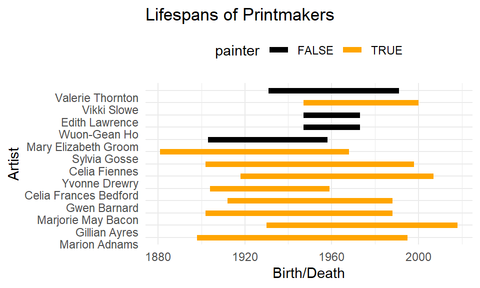

```r
printmaker_data <- subset(data, printmaker)


printmaker_data$birth[printmaker_data$death == 1947] <- 1947
printmaker_data$death[printmaker_data$birth == 1947] <- 2000
printmaker_data$birth[printmaker_data$death == 1973] <- 1947


printmaker_data <- transform(printmaker_data, artist = reorder(artist, birth))


ggplot(printmaker_data, aes(x = birth, y = artist, color = painter)) +
  geom_segment(aes(xend = death, yend = artist), size = 2) +
  scale_color_manual(values = c("FALSE" = "black", "TRUE" = "orange")) +
  labs(
    x = "Birth/Death",
    y = "Artist",
    title = "Lifespans of Printmakers",
  ) +
  theme_minimal() +
  theme(legend.position = "top") +
  guides(color = guide_legend(override.aes = list(size = 3))
  ) +
  scale_y_discrete(limits = printmaker_data$artist)
```

References:

1. https://data-science-master.github.io/lectures/05_web_scraping/05_web_scraping.html
2. https://chat.openai.com/c/5446217f-88f8-4fe7-9a06-e07324eeb890